# data609hw11

jim lung

November 15, 2018

## Section 12.1, Problem 1

$$\frac{dx}{dt} = \frac{d}{dt}\left( -e^t \right) = -e^t = -y$$
$$\frac{dy}{dt} = \frac{d}{dt}\left( e^t \right) = e^t = -x$$

## Section 12.1, Problem 6

The only point at which $\frac{dx}{dt} = \frac{dy}{dt} = 0$ is $(2, 1)$.

Integrating the equations,
$$x = \int \left(\frac{dx}{dt}\right)dt = -\int \left( y - 1 \right) dt = -t\left( y - 1 \right)$$
As $t \to \infty$, $x(t) \to \infty$ if $y_0 < 1$ or $x(t) \to -\infty$ if $y_0 > 1$.

$$y = \int \left(\frac{dy}{dt}\right)dt = \int \left( x - 2 \right) dt = t\left( x - 2 \right)$$

As $t \to \infty$, $y(t) \to \infty$ if $x_0 > 2$ or $y(t) \to -\infty$ if $x_0 < 2$.

Since $(x,y) \to (\pm \infty, \pm \infty)$ for $(x_0, y_0) \notin (2,1)$, the point is unstable.

## Section 12.2, Problem 7

### Part a

$$\frac{dt}{dx} = \left( \frac{dx}{dt} \right)^{-1} = \frac{1}{(a - by)x}$$
$$\frac{dy}{dx} = \frac{dy}{dt} \times \frac{dt}{dx} = \frac{(m - nx)y}{(a - by)x}$$

### Part b

$$\frac{1}{y} \frac{dy}{dx} = \frac{1}{x} \frac{m - nx}{a - by} \longrightarrow
\frac{ady}{y} - bdy = \frac{mdx}{x} - ndx$$

$$\int \frac{ady}{y} - \int bdy = \int \frac{mdx}{x} - \int ndx \longrightarrow
a\ln y - by + K_1 = m\ln x - nx + K_2$$

$$y^a e^{-by} = K x^m e^{-nx}$$

### Part c

$$\frac{d}{dy} f(y) = ay^{a-1} \times e^{-by} + (-be^{-by}) \times y^a =
y^{a-1}e^{-by} \left( a - by\right)$$

Setting $f^\prime = 0$ to find the maximum:
$$y^{a-1}e^{-by} \left( a - by\right) = 0 \longrightarrow a - by = 0 \longrightarrow y = \frac{a}{b}$$
At $y = \frac{a}{b}$,
$$f(\frac{a}{b}) = \left( \frac{a}{b} \right)^a e^{-a} = \left( \frac{a}{eb} \right)^a$$

$$\frac{d}{dx} g(x) = mx^{m-1} \times e^{-nx} + (-ne^{-ny}) \times x^m =
x^{m-1}e^{-nx} \left( m - nx\right)$$

Setting $g^\prime = 0$ to find the maximum:
$$x^{m-1}e^{-ny} \left( m - nx\right) = 0 \longrightarrow m - nx = 0 \longrightarrow x = \frac{m}{n}$$
At $x = \frac{m}{n}$,
$$g(\frac{m}{n}) = \left( \frac{m}{n} \right)^m e^{-m} = \left( \frac{m}{en} \right)^m$$

### Part d

The constant $K$ from part b is equivalent to
$$K = \frac{e^{K_1}}{e^{K_2}}$$
Where $K_1$ and $K_2$ are the integration constants from the left and right sides, respectively. As $(x, y) \to (m/n, a/b)$, it is clear from the provided equations that $dx/dt, dy/dt \to 0$.

Using this information, the constants can be solved for:
$$a \ln y - by + K_1 = 0 \longrightarrow e^{K_1} = \frac{y^a}{e^{by}}$$

$$m \ln x - ny + K_2 = 0 \longrightarrow e^{K_2} = \frac{x^m}{e^{nx}}$$

Thus, as $(x, y) \to (m/n, a/b)$,
$$\lim \left[ \left( \frac{y^a}{e^{by}}\right) \left( \frac{e^{nx}}{x^b} \right)\right] = \frac{e^{K_1}}{e^{K_2}} = K$$

### Part f

For $y_0 > a/b$, $f(y_0) < M_y$. This implies
$$\frac{M_y}{M_x} \left( \frac{x^m}{e^{nx}} \right) = \frac{y_0^a}{e^{by_0}} <M_y
\longrightarrow \frac{x^m}{e^{nx}} < M_x$$

## Section 12.3, Problem 1

### Critical Point

From above, the derivative is given by
$$f^\prime(y) = y^{a-1}e^{-by} \left( a - by\right)$$

Setting $f^\prime = 0$ to find the maximum:
$$y^{a-1}e^{-by} \left( a - by\right) = 0 \longrightarrow a - by = 0 \longrightarrow y = \frac{a}{b}$$

Since $y = \frac{a}{b}$ is the only root of the equation $f^\prime(y) = 0$, it is the only critical point of $f(y)$.

The second derivative is given by
$$f^{\prime\prime}(y) = a(a-1)y^{a-2} \times e^{-by} +ay^{a-1} \times -be^{-by}
+ b^2e^{-by} \times y^a + ay^{a - 1} \times -be^{-by}$$
$$f^{\prime\prime}(y) = y^{a - 2} e^{-by} \left(a^2 - 2aby - a + b^2 y^2\right)$$

### Limit

The limit of the equation $\lim_{y \to \infty} f(y)$ does not provide a useful limit. Using L’Hopital’s rule to take the derivative of the numerator and denominator, however, provides useful insight:
$$\lim_{y \to \infty} \frac{y^a}{e^{by}} =
\lim_{y \to \infty} \frac{\frac{d^{n}}{dy^n}y^a}{\frac{d^{n}}{dy^n}e^{by}} =
\lim_{y \to \infty} \frac{\prod_{i}^n \{a - i + 1\}y^{a-n}}{b^ne^{by}}$$

From this, it is clear that the denominator will grow much larger than the numerator; thus
$$\lim_{y \to \infty} f(y) = 0$$

## Section 12.5, Problem 1

```r
# function to implement Euler's method
euler <- function(dxdt, dydt, t0, x0, y0, delta_t, n) {
  # initial conditions
  t <- t0
  x <- x0
  y <- y0
  # run loop to get approximations
  for (i in 1:n) {
    t_i <- t[length(t)] + delta_t
    x_i <- x[length(x)] + f(x[length(x)], y[length(y)]) * delta_t
    y_i <- y[length(y)] + g(x[length(x)], y[length(y)]) * delta_t
    t <- c(t, t_i)
    x <- c(x, x_i)
    y <- c(y, y_i)
  }
  # return estimate
  return(data.frame(t, x, y))
}
# functions for dx/dt and dy/dt
f <- function(x, y) {return(2 * x + 3 * y)}
g <- function(x, y) {return(3 * x + 2 * y)}
# get results for delta_t and 0.5*delta_t
est_a <- euler(f, g, 0, 1, 1, 1/4, 3)
est_b <- euler(f, g, 0, 1, 1, 1/8, 6)
# calculate analytical solutions
soln <- data.frame(t = est_b$t,
                   x = 0.5 * exp(-est_b$t) + 0.5 * exp(5 * est_b$t),
                   y = -0.5 * exp(-est_b$t) + 0.5 * exp(5 * est_b$t))
```

The results of the above estimates (Euler’s method using $\Delta t$, Euler’s method using $\Delta t/2$, and the analytical solution) are presented below in tabular format and graphically on the following page.

| $t$ | $x_{E(\Delta t)}$ | $y_{E(\Delta t)}$ | $x_{E(\Delta t / 2)}$ | $y_{E(\Delta t / 2)}$ | $x_A$ | $y_A$ |
| --- | --- | --- | --- | --- | --- | --- |
| 0 | 1 | 1 | 1 | 1 | 1 | 0 |
| 0.125 | NA | NA | 1.625 | 1.625 | 1.375 | 0.4929 |
| 0.25 | 2.25 | 2.25 | 2.641 | 2.641 | 2.135 | 1.356 |
| 0.375 | NA | NA | 4.291 | 4.291 | 3.604 | 2.917 |
| 0.5 | 5.062 | 5.062 | 6.973 | 6.973 | 6.395 | 5.788 |
| 0.625 | NA | NA | 11.33 | 11.33 | 11.65 | 11.11 |
| 0.75 | 11.39 | 11.39 | 18.41 | 18.41 | 21.5 | 21.02 |

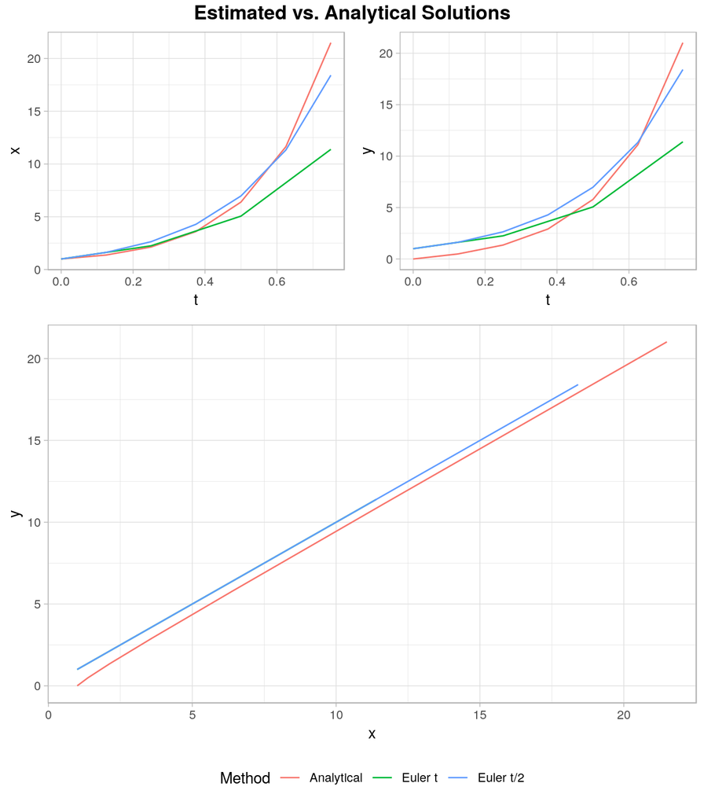